# Smoke Alarm Presence From NFIRS Data

Xianghui Dong

```r
require(ggplot2)
require(data.table)
require(bit64)
```

**The following code is based on the result of `read Data.Rmd` under Google drive folder `data\NFIRS`. If you load the uploaded R environment image `2015-09-16.RData`, this script can be executed directly without running `read Data.Rmd`.**

NFIRS data have some information about smoke alarm presence although there are limitations.

First there is no **“home fire”** category. The closest one is event type `111` under Structure Fire, which means *Building fire. Excludes confined fires.* (3-22 of [NFIRS 5.0 Complete Reference Guide](http://www.usfa.fema.gov/downloads/pdf/nfirs/NFIRS_Complete_Reference_Guide_2015.pdf))

### Basic Module

`DET_ALERT` : *The presence in the general area of fire origin of one or more detectors that was within the operational range of the detector(s) at the time of an incident.* (3-44)

```
      1 Detector alerted occupants
      2 Detector did not alert occupants
      U Unknown
```

Note the detector include but not limited to Smoke Alarms, see detailed definition later.

```r
det_basic = data_all$`2011basicincident`[grep('111', INC_TYPE)]$DET_ALERT
table(det_basic, useNA = "always")
```

```
## det_basic
##      1      2      3      U   <NA>
##  18546  25068      0  49557 198820
```

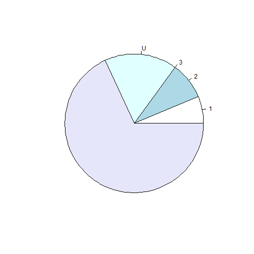

```r
pie(table(det_basic, useNA = "always"))
```

There are 291,991 building fires in 2011, *15% reported whether detector alerted occupants, 17% unknown, 68% have no input*.

### Structure Fire Module

`DETECTOR` *The existence of fire detection equipment within its designed range of the fire.* (5-15)

```
  1 Present.
  N None present.
  U Undetermined.
  Y Detectors Present
```

```r
# find event type of building fire
building_fire_2011 = data_all$`2011fireincident`[data_all$`2011basicincident`[grep('111', INC_TYPE)]]
table(building_fire_2011$DETECTOR, useNA = "always")
```

```
##
##      1      N      U   <NA>
##  67432  57344  46870 120345
```

So there are 67432 cases with detector present, which is way more than the count in basic module. One explanation could be sometimes the reporter knew detector was present but didn’t know if it alerted the occupants thus filled in “Unkown”. Thus the `DETECTOR` field in Fire module is better than `DET_ALERT` field in Basic module in reflecting smoke alarm presence.

`DET_TYPE` *Identifies the type of fire detection system that was present in the area of fire origin.* (5-16)

```
  1 Smoke.
  2 Heat.
  3 Combination smoke and heat in a single unit.
  4 Sprinkler, water flow detection.
  5 More than one type present.
  0 Detector type, other.
  U Undetermined.
```

```r
table(building_fire_2011$DET_TYPE, useNA = "always")
```

```
##
##      0      1      2      3      4      5      U   <NA>
##    491  52131    693   3793    990   2415   6918 224560
```

We decided Type 5 should more than likely include smoke alarm since it is the most basic and popular type. Type 2, 4, 0 don’t have smoke alarm but have other type of detectors instead.

```r
no_detector = building_fire_2011[DETECTOR == 'N']
head(no_detector)
```

```
##    STATE  FDID INC_DATE INC_NO EXP_NO VERSION NUM_UNIT NOT_RES BLDG_INVOL
## 1:    AK 11100  2182011   5943      0     5.0        0       Y          1
## 2:    AK 11100  4022011  11083      0     5.0        2       N          1
## 3:    AK 11100  5202011  17710      0     5.0        3       N          1
## 4:    AK 11100  7022011  24370      0     5.0        0       Y          1
## 5:    AK 11100  7062011  25020      0     5.0        1       N          1
## 6:    AK 11100  7292011  28910      0     5.0        1       N          1
##    ACRES_BURN LESS_1ACRE ON_SITE_M1 MAT_STOR1 ON_SITE_M2 MAT_STOR2
## 1:          0          Y        NNN         N         NA        NA
## 2:          0          Y        NNN         N         NA        NA
## 3:          0          Y        NNN         N         NA        NA
## 4:          0          Y        NNN         N         NA        NA
## 5:          0          Y        NNN         N         NA        NA
## 6:          0          Y        NNN         N         NA        NA
##    ON_SITE_M3 MAT_STOR3 AREA_ORIG HEAT_SOURC FIRST_IGN CONF_ORIG TYPE_MAT
```

[output cut: 97 more lines]

```r
other_detector = building_fire_2011[DET_TYPE %in% c("2", "4", "0")]
head(other_detector)
```

```
##    STATE  FDID INC_DATE  INC_NO EXP_NO VERSION NUM_UNIT NOT_RES BLDG_INVOL
## 1:    AK 23100  1122011 0001120      0     5.0        0       Y         NA
## 2:    AK 23100  8062011 0021988      0     5.0       20       N          1
## 3:    AK 25100  1212011 0000029      0     5.0        0       Y          1
## 4:    AK 31900  1182011 0100019      0     5.0        1       N          1
## 5:    AK 36110  7112011 0000001      0     5.0        0       Y          0
## 6:    AL 00102  4122011 1114781      0     5.0        1       N         NA
##    ACRES_BURN LESS_1ACRE ON_SITE_M1 MAT_STOR1 ON_SITE_M2 MAT_STOR2
## 1:         NA          Y         NA        NA         NA        NA
## 2:         NA          Y         NA        NA         NA        NA
## 3:          0          Y         NA        NA         NA        NA
## 4:          0          Y         NA        NA         NA        NA
## 5:         NA          Y        NNN         N         NA        NA
## 6:         NA          Y         NA        NA         NA        NA
##    ON_SITE_M3 MAT_STOR3 AREA_ORIG HEAT_SOURC FIRST_IGN CONF_ORIG TYPE_MAT
```

[output cut: 97 more lines]

```r
no_smoke_alarm = rbindlist(list(no_detector, other_detector))
head(no_smoke_alarm)
```

```
##    STATE  FDID INC_DATE INC_NO EXP_NO VERSION NUM_UNIT NOT_RES BLDG_INVOL
## 1:    AK 11100  2182011   5943      0     5.0        0       Y          1
## 2:    AK 11100  4022011  11083      0     5.0        2       N          1
## 3:    AK 11100  5202011  17710      0     5.0        3       N          1
## 4:    AK 11100  7022011  24370      0     5.0        0       Y          1
## 5:    AK 11100  7062011  25020      0     5.0        1       N          1
## 6:    AK 11100  7292011  28910      0     5.0        1       N          1
##    ACRES_BURN LESS_1ACRE ON_SITE_M1 MAT_STOR1 ON_SITE_M2 MAT_STOR2
## 1:          0          Y        NNN         N         NA        NA
## 2:          0          Y        NNN         N         NA        NA
## 3:          0          Y        NNN         N         NA        NA
## 4:          0          Y        NNN         N         NA        NA
## 5:          0          Y        NNN         N         NA        NA
## 6:          0          Y        NNN         N         NA        NA
##    ON_SITE_M3 MAT_STOR3 AREA_ORIG HEAT_SOURC FIRST_IGN CONF_ORIG TYPE_MAT
```

[output cut: 97 more lines]

```r
setkey(no_smoke_alarm, STATE, FDID, INC_DATE, INC_NO, EXP_NO)
no_smoke_alarm_address = merge(no_smoke_alarm, data_all$`2011incidentaddress`) # Note Rstudio will not show columns after about 100 in data viewer. You can use utils::View() instead for this kind of data.
head(no_smoke_alarm_address)
```

```
##    STATE  FDID INC_DATE INC_NO EXP_NO VERSION NUM_UNIT NOT_RES BLDG_INVOL
## 1:    AK 11100  2182011   5943      0     5.0        0       Y          1
## 2:    AK 11100  4022011  11083      0     5.0        2       N          1
## 3:    AK 11100  5202011  17710      0     5.0        3       N          1
## 4:    AK 11100  7022011  24370      0     5.0        0       Y          1
## 5:    AK 11100  7062011  25020      0     5.0        1       N          1
## 6:    AK 11100  7292011  28910      0     5.0        1       N          1
##    ACRES_BURN LESS_1ACRE ON_SITE_M1 MAT_STOR1 ON_SITE_M2 MAT_STOR2
## 1:          0          Y        NNN         N         NA        NA
## 2:          0          Y        NNN         N         NA        NA
## 3:          0          Y        NNN         N         NA        NA
## 4:          0          Y        NNN         N         NA        NA
## 5:          0          Y        NNN         N         NA        NA
## 6:          0          Y        NNN         N         NA        NA
##    ON_SITE_M3 MAT_STOR3 AREA_ORIG HEAT_SOURC FIRST_IGN CONF_ORIG TYPE_MAT
```

[output cut: 111 more lines]

With `no_smoke_alarm_address` we can build a geography profile for cases without smoke alarm present.